# Project Assignment 1 - Reproducible Research

## Imputing missing values

1. Calculate and report the total number of missing values in the dataset (i.e. the total number of rows with NAs)

```r
sum_na <- sum(is.na(df$steps))
sum_na
```

```
## [1] 2304
```

2. Devise a strategy for filling in all of the missing values in the dataset. The strategy does not need to be sophisticated. For example, you could use the mean/median for that day, or the mean for that 5-minute interval, etc.

```r
#A vector that contains the mean of steps in each interval
m_iv <-  mean(df_avg$steps)
```

3. Create a new dataset that is equal to the original dataset but with the missing data filled in.

```r
#creating a new dataset to not modify the original one
df_na <- df
#substituting the NAs by the mean
df_na[is.na(df$steps),]$steps  <- m_iv
```

4. Make a histogram of the total number of steps taken each day and Calculate and report the mean and median total number of steps taken per day. Do these values differ from the estimates from the first part of the assignment? What is the impact of imputing missing data on the estimates of the total daily number of steps?

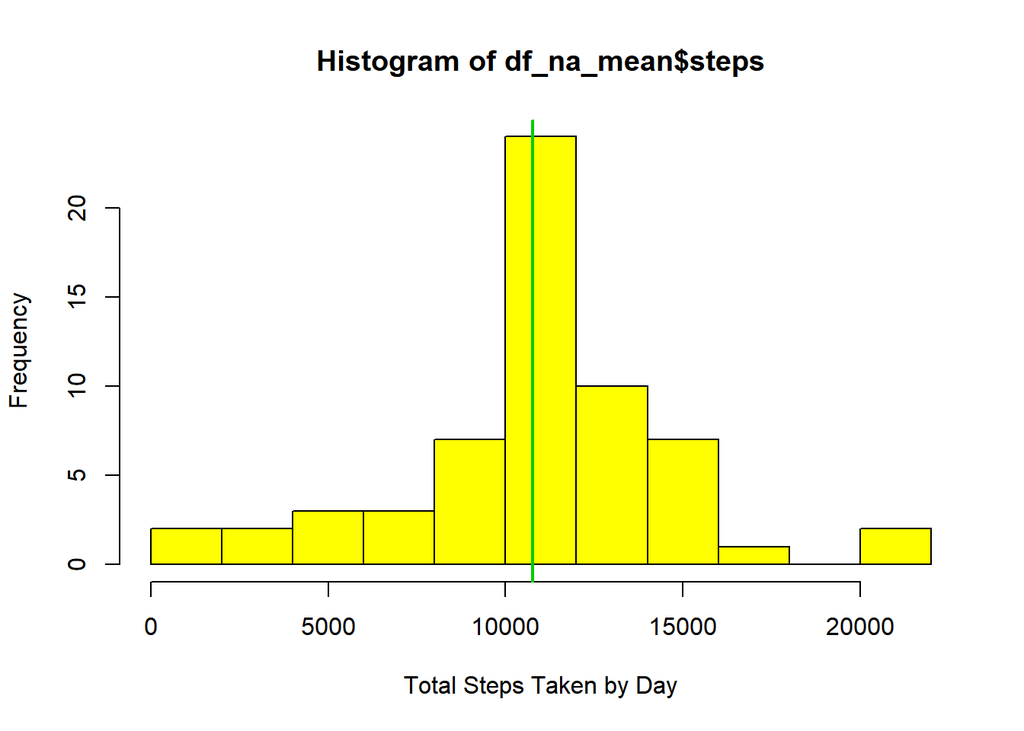

```r
#tidying the data frame for easy calculation of the total number of steps
df_na_mean <- summarize(group_by(df_na, date), steps = sum(steps))
#plotting the histogram
hist(df_na_mean$steps, breaks = 8, col = 7, xlab = "Total Steps Taken by Day")
abline(v = mean(df_na_mean$steps), lwd = 2, col = 3)
```

```r
median(df_na_mean$steps)
```

```
## [1] 10766.19
```

```r
mean(df_na_mean$steps)
```

```
## [1] 10766.19
```

As we can see, the median and mean have the same values. Furthermore, those values standout among the others, making the data less reliable than the one from the first part of the assignment. That is the main reason why it is much more important to exclude the missing data and to use only the complete observations.

## Are there differences in activity patterns between weekdays and weekends?

1. Create a new factor variable in the dataset with two levels – “weekday” and “weekend” indicating whether a given date is a weekday or weekend day.

```r
#changing system locale
Sys.setlocale("LC_ALL","English")
```

```
## [1] "LC_COLLATE=English_United States.1252;LC_CTYPE=English_United States.1252;LC_MONETARY=English_United States.1252;LC_NUMERIC=C;LC_TIME=English_United States.1252"
```

```r
#transforming to date
df_cc$date <- as.Date(df_cc$date)
#creating new df
df_cc_wd <- df_cc %>%
        mutate(Day = as.factor(ifelse(weekdays(df_cc$date) == "Sunday" | (weekdays(df_cc$date)) == "Saturday", "Weekend", "Weekday")))
```

2. Make a panel plot containing a time series plot (i.e. type = “l”) of the 5-minute interval (x-axis) and the average number of steps taken, averaged across all weekday days or weekend days (y-axis). See the README file in the GitHub repository to see an example of what this plot should look like using simulated data.

[figure not shown]

```r
#df with the average steps
df_mean_wd <- summarize(group_by(df_cc_wd, interval, Day), steps = sum(steps))
library(ggplot2)
g <- ggplot(df_mean_wd, aes(interval, steps))
g + geom_point() +
        xlab("Daily Intervals") + ylab("Average Number of Steps Taken") +
        ggtitle(expression("Total Number of Steps on Daily Intervals by Day Type ")) +
        theme(legend.title = element_blank()) +
        facet_grid(. ~ Day) +
        geom_line()
```